# Coverage of DOAJ journals in WoS and Scopus dataset

- Show All Code
- Hide All Code

Author

Affiliation

Philippe Mongeon

Dalhousie University

Published

March 18, 2024

## Data sources

- DOAJ data dump (downloaded on March 6th, 2024).
- Scopus journal list (downloaded on March 6th, 2024) - last updated February 2024.
- WoS journal list (downloaded on March 6th, 2024 - last updated Feb 19th, 2024).
- OpenAlex (February 2024 data dump).
- World Bank classification of countries by income group (downloaded March 18th): https://datahelpdesk.worldbank.org/knowledgebase/articles/906519-world-bank-country-and-lending-groups.

# Create database

```r
#
# # ----------------------------
# # countries
# # ----------------------------
#
# dbExecute(db,
#           "CREATE TABLE countries (
#             country_code CHAR(2),
#             economy TEXT,
#             region TEXT,
#             income_group TEXT,
#             PRIMARY KEY (country_code)
#             );")
#
# # ----------------------------
# # doaj_countries_publishers
# # ----------------------------
#
# dbExecute(db,
#           "CREATE TABLE doaj_countries_publishers (
#             id SMALLINT,
#             country TEXT,
#             country_code CHAR(2),
#             PRIMARY KEY (id),
#             FOREIGN KEY (country_code) REFERENCES _countries (country_code)
#             );
#           ")
#
# # ----------------------------
# # doaj
# # ----------------------------
#
# dbExecute(db,
#           "CREATE TABLE doaj_journals (
#             id TEXT,
#             title TEXT,
#             oa_start_year SMALLINT,
#             country_publisher_id SMALLINT,
#             oa_type TEXT,
#             PRIMARY KEY (id),
#             FOREIGN KEY (country_publisher_id)
#               REFERENCES _doaj_countries_publishers (id)
#           );")
#
# # ----------------------------
# # doaj_issns
# # ----------------------------
#
# dbExecute(db,
#           "CREATE TABLE doaj_issns (
#             doaj_id TEXT,
#             issn TEXT,
#             type TEXT,
#           PRIMARY KEY (doaj_id, issn),
#           FOREIGN KEY (doaj_id) REFERENCES _doaj (id));")
#
# # ----------------------------
# # doaj_languages
# # ----------------------------
#
# dbExecute(db,
#           "CREATE TABLE doaj_languages (
#             doaj_id TEXT,
#             language TEXT,
#           PRIMARY KEY (doaj_id, language),
#           FOREIGN KEY (doaj_id) REFERENCES _doaj (id));")
#
# # ----------------------------
# # journals_disciplines
# # ----------------------------
#
# dbExecute(db,
#   "CREATE TABLE journals_disciplines (
#     doaj_id text,
#     discipline varchar(15),
#   PRIMARY KEY (doaj_id, discipline),
#   FOREIGN KEY (doaj_id) REFERENCES doaj (id));")
```

## Data processing

### Country income level

```r
countries <- read_csv("data/country_classification.csv")
```

### DOAJ

#### Import DOAJ journal list

```r
# Load DOAJ journal list
doaj_data <- read_csv("data/journalcsv__doaj_20240306_1820_utf8.csv") %>%
  select(id = `URL in DOAJ`,
         title = `Journal title`,
         oa_start_year = `When did the journal start to publish all content using an open license?`,
         alternative_title = `Alternative title`,
         issn = `Journal ISSN (print version)`,
         eissn = `Journal EISSN (online version)`,
         language = `Languages in which the journal accepts manuscripts`,
         country_publisher = `Country of publisher`,
         former_issn = `Continues`,
         new_issn = `Continued By`,
         apc = APC) %>%
  mutate(id = str_remove(id, "https://doaj.org/toc/"))
```

#### Publishing countries

```r
doaj_countries_publishers <- doaj_data %>%
  left_join(countries, by=c("country_publisher"="economy")) %>%
  select(country_publisher, country_code) %>%
  unique() %>%
  rownames_to_column("id")
```

#### DOAJ journals

```r
doaj_journals <- doaj_data %>%
  mutate(id = str_remove(id, "https://doaj.org/toc/")) %>%
  mutate(oa_type = ifelse(apc == "Yes","Gold","Diamond")) %>%
  left_join(doaj_countries_publishers %>%
              rename(country_publisher_id = id),
            by="country_publisher") %>%
  select(id, title, oa_start_year, country_publisher_id, oa_type)
```

#### Language

```r
doaj_languages <- doaj_data %>%
  select(doaj_id = id, language) %>%
  separate_rows(language, sep = ",") %>%
  mutate(language = str_squish(language)) %>%
  unique()
```

#### ISSNs

```r
   doaj_issns <- bind_rows(doaj_data %>%
                         select(doaj_id = id, issn) %>%
                         mutate(type = "issn"),
                       doaj_data %>%
                         select(doaj_id = id, issn = eissn) %>%
                         mutate(type = "eissn"),
                       doaj_data %>%
                         select(doaj_id = id, issn = former_issn) %>%
                         mutate(type = "former issn"),
                       doaj_data %>%
                         select(doaj_id = id, issn = new_issn) %>%
                         mutate(type = "new issn")) %>%
     unique() %>%
     mutate(doaj_id = str_remove(doaj_id, "https://doaj.org/toc/"))
```

#### Journal titles

```r
doaj_titles <- doaj_data %>%
  select(doaj_id = id, title) %>%
  mutate(type = "main_title") %>%
    bind_rows(doaj_data %>%
                select(doaj_id = id, title = alternative_title) %>%
                mutate(type = "alternative_title")) %>%
  drop_na() %>%
  unique()
```

### Scopus

We do not exclude journals that were discontinued from Scopus in January 2024, and do not include the newly accepted journals in the process of being added to Scopus.

#### Import Scopus journal list

```r
scopus_data <- read_xlsx("data/ext_list_February_2024.xlsx", sheet = 1) %>%
  select(id = 1,
         title = 2,
         issn = 3,
         eissn = 4,
         active = `Active or Inactive`,
         discontinued_quality_issues = 7,
         language = 8,
         oa_status = 10,
         type = 13,
         related_title1 = 15,
         related_title2 = 16,
         related_title3 = 17,
         related_title4 = 18,
         publisher = 19,
         life_sciences = 22,
         social_sciences = 23,
         physical_sciences = 24,
         health_sciences = 25
         ) %>%
  mutate(life_sciences = as.logical(ifelse(is.na(life_sciences),F,T))) %>%
  mutate(social_sciences = as.logical(ifelse(is.na(social_sciences),F,T))) %>%
  mutate(physical_sciences = as.logical(ifelse(is.na(physical_sciences),F,T))) %>%
  mutate(health_sciences = as.logical(ifelse(is.na(health_sciences),F,T))) %>%
  mutate(active = as.logical(ifelse(active == "Active",T,F))) %>%
  mutate(active = as.logical(ifelse(discontinued_quality_issues == "Discontinued by Scopus",T,F)))
```

#### Journals

```r
scopus_journals <- scopus_data %>%
  select(id, title, active, discontinued_quality_issues, type, publisher,
         life_sciences, social_sciences, physical_sciences,
         health_sciences)
```

#### ISSNs

```r
scopus_issns <- bind_rows(scopus_data %>%
                            select(scopus_id = id, issn) %>%
                            mutate(type = "issn") %>%
                            drop_na() %>%
                            mutate(issn = ifelse(str_length(issn)==7,
                                                 str_c("0",issn),
                                                 issn)) %>%
                            mutate(issn = str_c(str_sub(issn,1,4),
                                                "-",
                                                str_sub(issn,5,8))),
                          scopus_data %>%
                            select(scopus_id = id, issn = eissn) %>%
                            mutate(type = "eissn") %>%
                            drop_na() %>%
                            mutate(issn = ifelse(str_length(issn) ==7,
                                                 str_c("0",issn),
                                                 issn)) %>%
                            mutate(issn = str_c(str_sub(issn,1,4),
                                                "-",
                                                str_sub(issn,5,8)))) %>%
  unique()
```

#### Journal titles

```r
scopus_titles <- bind_rows(scopus_data %>%
                             select(scopus_id = id, title) %>%
                             mutate(type = "title"),
                           scopus_data %>%
                             select(scopus_id = id, title = related_title1) %>%
                             mutate(type = "related_title"),
                           scopus_data %>%
                             select(scopus_id = id, title = related_title2) %>%
                             mutate(type = "related_title"),
                           scopus_data %>%
                             select(scopus_id = id, title = related_title3) %>%
                             mutate(type = "related_title"),
                           scopus_data %>%
                             select(scopus_id = id, title = related_title4) %>%
                             mutate(type = "related_title")) %>%
  drop_na() %>%
  unique()

# Manually clean journal titles with square brackets
scopus_titles %>%
  filter(str_detect(title, "\\[")) %>%
  writexl::write_xlsx("data/scopus_journal_titles_to_clean.xlsx")

scopus_titles <- bind_rows(scopus_titles %>%
  filter(!str_detect(title, "\\[")),
  read_xlsx("data/scopus_journal_titles_cleaned.xlsx")) %>%
  unique()
```

### Web of Science

#### Import WOS journal list

```r
wos_data <- bind_rows(read_csv("data/wos-core_AHCI 2024-February-19.csv") %>%
                        mutate(index = "ahci"),
                      esci<-read_csv("data/wos-core_ESCI 2024-February-19.csv") %>%
                        mutate(index = "esci"),
                      ssci<-read_csv("data/wos-core_SSCI 2024-February-19.csv") %>%
                        mutate(index = "ssci"),
                      scie<-read_csv("data/wos-core_SCIE 2024-February-19.csv") %>%
                        mutate(index = "scie")) %>%
   select(title = `Journal title`,
         issn = ISSN,
         eissn = eISSN,
         publisher =`Publisher name`,
         language = Languages,
         wos_category = `Web of Science Categories`,
         index) %>%
  group_by(title, issn, eissn, publisher, language, wos_category) %>%
  mutate(index, str_c(index, collapse = ",")) %>%
  unique() %>%
  rownames_to_column("id")
```

#### Journals

```r
wos_journals <- wos_data %>%
  select(-index)
```

#### Indexes

```r
wos_journals_indexes <- wos_data %>%
  select(wos_id = id, index) %>%
  separate_rows(index, sep=",")
```

#### ISSNs

```r
wos_journals_issns <- bind_rows(wos_data %>%
                                  select(wos_id = id, issn) %>%
                                  mutate(type = "issn") %>%
                                  drop_na(),
                                wos_data %>%
                                  select(wos_id = id, issn = eissn) %>%
                                  mutate(type = "eissn") %>%
                                  drop_na()) %>%
  unique()
```

### Openalex

#### Import OpenAlex journal data

```r
openalex_data <- read_csv("data/openalex_Feb_2024.csv")
```

#### OpenAlex journals

```r
openalex_journals <- openalex_data %>%
  select(id,
         title = display_name,
         is_oa,
         is_in_doaj,
         type,
         country_code,
         publisher)
```

#### ISSNs

```r
openalex_issns <- bind_rows(openalex_data %>%
                              select(openalex_id = id, issn = issn_l) %>%
                              mutate(type = "issn_l") %>%
                              drop_na(),
                            openalex_data %>%
                              select(openalex_id = id, issn) %>%
                              separate_rows(issn, sep = ",") %>%
                              mutate(type = "issn") %>%
                              drop_na() %>%
                              mutate(issn = str_remove_all(issn, "\"")) %>%
                              mutate(issn = str_remove_all(issn, "\\[")) %>%
                              mutate(issn = str_remove_all(issn, "\\]"))) %>%
  unique()
```

### Journal matching

#### DOAJ and WoS

```r
doaj_wos_issn_match <- doaj_issns %>%
  inner_join(wos_journals_issns, by="issn") %>%
  select(doaj_id, wos_id) %>%
  mutate(matched_by = "issn")

doaj_wos_title_match <- doaj_titles %>%
  filter(!doaj_id %in% doaj_wos_issn_match$doaj_id) %>%
  mutate(title = str_to_lower(title)) %>%
  inner_join(wos_journals %>%
               select(wos_id = id, title) %>%
               mutate(title = str_to_lower(title)), by="title") %>%
  select(doaj_id, wos_id) %>%
  mutate(matched_by = "title")

doaj_wos_matches <- bind_rows(doaj_wos_issn_match,
                              doaj_wos_title_match) %>%
  unique()
```

#### DOAJ and Scopus

```r
doaj_scopus_issn_match <- doaj_issns %>%
  inner_join(scopus_issns, by="issn") %>%
  select(doaj_id, scopus_id) %>%
  mutate(matched_by = "issn")

doaj_scopus_title_match <- doaj_titles %>%
  filter(!doaj_id %in% doaj_scopus_issn_match$doaj_id) %>%
  select(doaj_id, title) %>%
  mutate(title = str_to_lower(title)) %>%
  inner_join(scopus_journals %>%
               select(scopus_id = id, title) %>%
               mutate(title = str_to_lower(title)), by="title") %>%
  select(doaj_id, scopus_id) %>%
  mutate(matched_by = "title")

doaj_scopus_matches <- bind_rows(doaj_scopus_issn_match,
                              doaj_scopus_title_match) %>%
  unique()
```

#### DOAJ and OpenAlex

```r
doaj_openalex_issn_match <- doaj_issns %>%
  inner_join(openalex_issns, by="issn") %>%
  select(doaj_id, openalex_id) %>%
  mutate(matched_by = "issn")

doaj_openalex_title_match <- doaj_titles %>%
  filter(!doaj_id %in% doaj_openalex_issn_match$doaj_id) %>%
  mutate(title = str_to_lower(title)) %>%
  inner_join(openalex_journals %>%
               select(openalex_id = id, title) %>%
               mutate(title = str_to_lower(title)), by="title") %>%
  select(doaj_id, openalex_id) %>%
  mutate(matched_by = "title")

doaj_openalex_matches <- bind_rows(doaj_openalex_issn_match,
                              doaj_openalex_title_match) %>%
  unique()
```

### Checks and manual matches

1. Journals listed as in_doaj = T in Openalex but that were not matched in our process
2. Journals listed as OA journals in the Scopus list that were not matched in our process.

#### OpenAlex

```r
library(kableExtra)
openalex_in_doaj <- openalex_data %>%
  filter(is_in_doaj == T)

openalex_data %>%
  left_join(doaj_openalex_matches , by=c("id"="openalex_id")) %>%
  mutate(matched = ifelse(is.na(doaj_id),0,1)) %>%
  group_by(is_in_doaj) %>%
  mutate(total = n()) %>%
  mutate(n_matched = sum(matched)) %>%
  select(is_in_doaj, n_matched, total) %>%
  unique() %>%
  kbl()
```

| is_in_doaj | n_matched | total |
| --- | --- | --- |
| FALSE | 1334 | 273680 |
| TRUE | 19476 | 19691 |

```r
openalex_data %>%
  filter(is_in_doaj == T) %>%
  anti_join(doaj_openalex_matches, by = c("id"="openalex_id")) %>%
  writexl::write_xlsx("data/openalex_journals_to_match.xslx")

dbReadTable(db, "doaj") %>%
  left_join(dbReadTable(db, "doaj_issns"), by=c("id" = "doaj_id")) %>%
  group_by(id) %>%
  mutate(issn = str_c(issn, collapse = ", ")) %>%
  unique() %>%
  ungroup() %>%
  writexl::write_xlsx("data/doaj_for_matching.xlsx")
```

#### Add manual matches to data

```r
openalex_manual_matches <- read_xlsx("data/openalex_journals_manually_matched.xlsx")

doaj_openalex_matches <- bind_rows(doaj_openalex_matches,
                                   openalex_manual_matches %>%
                                     filter(doaj_id != 0) %>%
                                     select(doaj_id, openalex_id = id) %>%
                                     mutate(matched_by = "manual"))

doaj_openalex_matches <- doaj_openalex_matches %>%
  mutate(openalex_id = str_remove(openalex_id, "https://openalex.org/S"))
```

#### Scopus

```r
scopus_data %>%
  left_join(doaj_scopus_matches, by = c("id" = "scopus_id")) %>%
  mutate(matched = ifelse(!is.na(doaj_id),1,0)) %>%
  group_by(oa_status) %>%
  mutate(total = n()) %>%
  mutate(n_matched = sum(matched)) %>%
  select(oa_status, n_matched, total) %>%
  unique() %>%
  kbl()
```

| oa_status | n_matched | total |
| --- | --- | --- |
| NA | 972 | 38074 |
| Unpaywall Open Acess | 7230 | 7405 |

```r
scopus_data %>%
  filter(!is.na(oa_status)) %>%
  anti_join(doaj_scopus_matches, by = c("id"="scopus_id")) %>%
  writexl::write_xlsx("data/scopus_journals_to_match.xslx")
```

#### Add manual matches to data

```r
scopus_manual_matches <- read_xlsx("data/scopus_journals_manually_matched.xlsx")

doaj_scopus_matches <- bind_rows(doaj_scopus_matches,
                                   scopus_manual_matches %>%
                                     filter(doaj_id != 0) %>%
                                     select(doaj_id, scopus_id = id) %>%
                                     mutate(matched_by = "manual"))
```

### Discipline classification

```r
# doaj_issns <- dbReadTable(db, "doaj_issns")
# old_data <- dbReadTable(db, "data")
#
# dbWriteTable(db, "journals_disciplines",
#              doaj_issns %>%
#                filter(!doaj_id %in% dbReadTable(db,"journals_disciplines")$doaj_id) %>%
#                inner_join(old_data %>% filter(!is.na(issn)) %>% select(issn, nsf), by="issn") %>%
#                select(doaj_id, discipline = nsf) %>%
#                separate_rows(discipline, sep = ";") %>%
#                mutate(discipline = str_squish(discipline)) %>%
#                unique() %>%
#                drop_na(),
#              row.names = F,
#              append = T)
#
# dbWriteTable(db, "journals_disciplines",
#              doaj_issns %>%
#                filter(!doaj_id %in% dbReadTable(db,"journals_disciplines")$doaj_id) %>%
#                inner_join(old_data %>% filter(!is.na(eissn)) %>% select(issn = eissn, nsf), by="issn") %>%
#                select(doaj_id, discipline = nsf) %>%
#                separate_rows(discipline, sep = ";") %>%
#                mutate(discipline = str_squish(discipline)) %>%
#                unique() %>%
#                drop_na(),
#              row.names = F,
#              append = T)
#
# dbWriteTable(db, "journals_disciplines",
#              dbReadTable(db, "doaj_titles") %>%
#                filter(!doaj_id %in% dbReadTable(db,"journals_disciplines")$doaj_id) %>%
#                inner_join(old_data %>% filter(!is.na(journal_title)) %>% select(title = journal_title, nsf), by="title") %>%
#                select(doaj_id, discipline = nsf) %>%
#                separate_rows(discipline, sep = ";") %>%
#                mutate(discipline = str_squish(discipline)) %>%
#                unique() %>%
#                drop_na(),
#              row.names = F,
#              append = T)
```

#### Automatic classification based on previous classification

```r
# library(tidytext)
# library(textstem)
# subject_discipline <- dbReadTable(db, "doaj") %>%
#   separate_rows(subject, sep = ",") %>%
#   mutate(subject = str_squish(subject)) %>%
#   mutate(subject = str_sub(subject,1,str_locate(subject,":")[,1]-1)) %>%
#   select(id, subject) %>%
#   inner_join(dbReadTable(db, "journals_disciplines"), by=c("id" = "doaj_id")) %>%
#   group_by(subject, discipline) %>%
#   summarize(n = n()) %>%
#   ungroup() %>%
#   group_by(subject) %>%
#   mutate(total = sum(n)) %>%
#   mutate(pct = n/total) %>%
#   drop_na()
#
# journal_discipline <- dbReadTable(db, "doaj") %>%
#   filter(!id %in% dbReadTable(db, "journals_disciplines")$doaj_id) %>%
#   separate_rows(subject, sep = ",") %>%
#   mutate(subject = str_squish(subject)) %>%
#   mutate(subject = str_sub(subject,1,str_locate(subject,":")[,1]-1)) %>%
#   select(id, title, subject) %>%
#   inner_join(subject_discipline, by="subject") %>%
#   group_by(id, discipline) %>%
#   mutate(total_score = sum(pct)) %>%
#   ungroup() %>%
#   group_by(id) %>%
#   mutate(best_match = ifelse(total_score == max(total_score),T,F)) %>%
#   filter(best_match == T) %>%
#   select(doaj_id = id, discipline) %>%
#   unique()
```

#### Create file with journals to manually classify

```r
# dbReadTable(db, "doaj") %>%
#   filter(!id %in% dbReadTable(db, "journals_disciplines")$doaj_id) %>%
#   writexl::write_xlsx("data/journals_to_classify.xlsx")
```

#### update data

```r
 #
 # journals_disciplines <- dbReadTable(db, "journals_disciplines") %>%
 #   bind_rows(read_xlsx("data/journals_to_classify.xlsx") %>%
 #               select(doaj_id = id, discipline) %>%
 #               unique())
```

### Authorship data

#### Getting the authorship data from Google Big Query

```sql
-- Query executed on March 8th 2024
/*
SELECT a.source_id,
       c.publication_year,
       d.institution_id,
       count(author_id) as n_publications
FROM `global-timer-415013.diamon_oa.openalex_sources`as a
JOIN insyspo.publicdb_openalex_2024_02_rm.works_primary_location as b
  on b.source_id = a.source_id
JOIN insyspo.publicdb_openalex_2024_02_rm.works as c
  on c.id = b.id
JOIN insyspo.publicdb_openalex_2024_02_rm.works_authorships as d
  on d.work_id = c.id
WHERE c.publication_year between 2019 and 2023 and c.type='article'
GROUP BY a.source_id, c.publication_year, d.institution_id"
*/
```

#### Import OpenAlex authorship data

```r
openalex_authorship <- read_csv("data/openalex_institutions_work_count_per_year.csv") %>%
  mutate(source_id = str_remove(source_id, "https://openalex.org/S")) %>%
  mutate(institution_id = str_remove(institution_id, "https://openalex.org/I"))
```

#### Import OpenAlex institution data

```r
openalex_institutions <- read_csv("data/openalex_institutions.csv") %>%
  select(id, name = display_name, country_code, country) %>%
  mutate(id = str_remove(id, "https://openalex.org/I"))
```

# Analysis

```r
journals_disciplines <- read_csv("data/journals_disciplines.csv") %>%
  bind_rows(read_xlsx("data/journals_to_classify.xlsx") %>%
               select(doaj_id = id, discipline) %>%
               unique())

doaj_coverage <- doaj_journals %>%
  select(id) %>%
  unique() %>%
  mutate(coverage = case_when(
    id %in% doaj_scopus_matches$doaj_id ~ "WoS or Scopus",
    id %in% filter(doaj_wos_matches %>%
                     inner_join(wos_journals_indexes, by="wos_id"),
                   index == "esci")$doaj_id ~ "WoS - ESCI",
    id %in% filter(doaj_wos_matches %>%
                     inner_join(wos_journals_indexes, by="wos_id"),
                   index != "esci")$doaj_id ~ "WoS or Scopus",
    .default = "Not in WoS or Scopus"))
```

## Coverage of DOAJ journals in OpenAlex, WoS and, Scopus

### Overlap

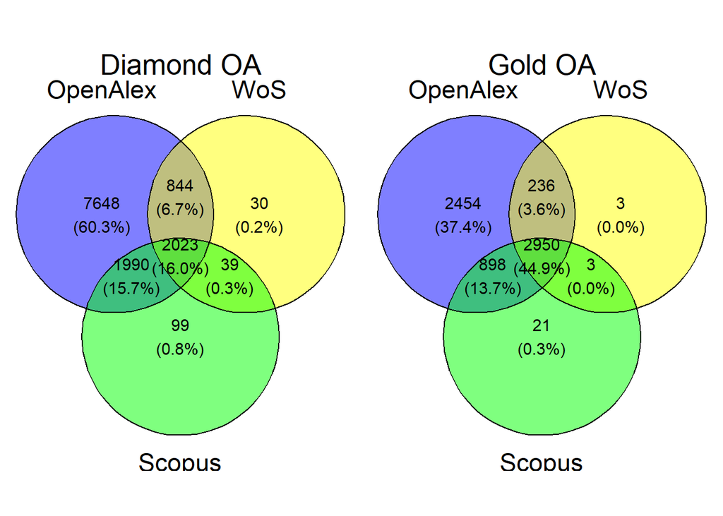

```r
library("ggVennDiagram")
library("ggvenn")


plot_overlap_diamond <- list(
  OpenAlex = unique(doaj_journals %>%
                      filter(oa_type == "Diamond") %>%
                      inner_join(doaj_openalex_matches,
                                 by=c("id" = "doaj_id")))$id,
  WoS = unique(doaj_journals %>%
                      filter(oa_type == "Diamond") %>%
                      inner_join(doaj_wos_matches,
                                 by=c("id" = "doaj_id")))$id,
  Scopus = unique(doaj_journals %>%
                      filter(oa_type == "Diamond") %>%
                      inner_join(doaj_scopus_matches,
                                 by=c("id" = "doaj_id")))$id
  ) %>%
  ggvenn(stroke_size = 0.5) +
  ggtitle("Diamond OA") +
  theme(plot.title = element_text(size = 20, hjust = .5))


plot_overlap_gold <- list(
  OpenAlex = unique(doaj_journals %>%
                      filter(oa_type == "Gold") %>%
                      inner_join(doaj_openalex_matches,
                                 by=c("id" = "doaj_id")))$id,
  WoS = unique(doaj_journals %>%
                      filter(oa_type == "Gold") %>%
                      inner_join(doaj_wos_matches,
                                 by=c("id" = "doaj_id")))$id,
  Scopus = unique(doaj_journals %>%
                      filter(oa_type == "Gold") %>%
                      inner_join(doaj_scopus_matches,
                                 by=c("id" = "doaj_id")))$id
  ) %>%
  ggvenn(stroke_size = 0.5) +
  ggtitle("Gold OA") +
  theme(plot.title = element_text(size = 20, hjust = .5))

ggarrange(plot_overlap_diamond, plot_overlap_gold)
```

```r
ggsave("tables and figures/overlap.tiff", device = "tiff", width = 8, height = 6, units = "in", dpi=300)
```

### Coverage

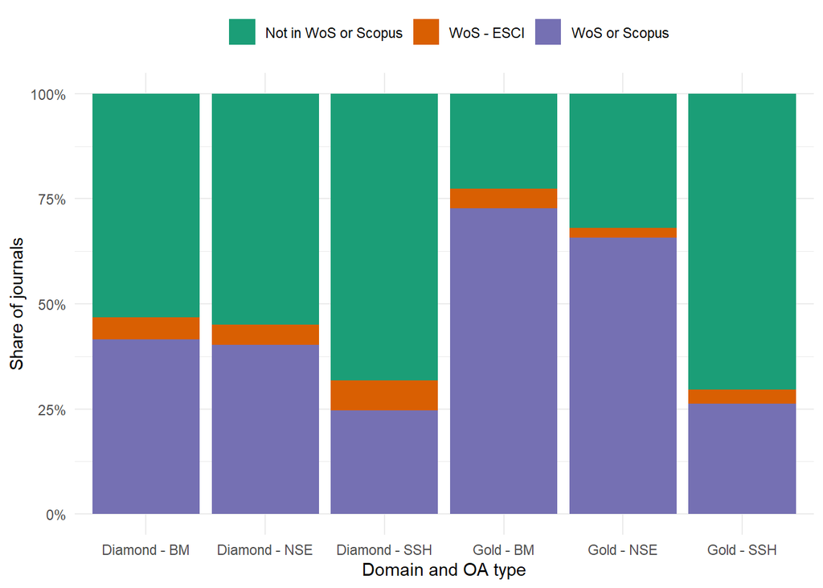

```r
plot_coverage <- doaj_journals %>%
  inner_join(doaj_coverage, by="id") %>%
  inner_join(journals_disciplines, by=c("id"="doaj_id")) %>%
  filter(discipline != 'n/a') %>%
  mutate(group = str_c(oa_type, " - ", discipline)) %>%
  unique() %>%
  group_by(group) %>%
  mutate(total = n()) %>%
  group_by(group, coverage) %>%
  mutate(n = n()) %>%
  select(group, coverage, n, total) %>%
  unique() %>%
  mutate(p = n/total) %>%
  ggplot() +
  aes(y=p, x=group, fill=coverage) +
  geom_bar(stat="identity") +
  ylab("Share of journals") +
  xlab("Domain and OA type") +
  theme_minimal() +
  theme(plot.title = element_text(size = 10, hjust = .5)) +
  theme(legend.title=element_blank()) +
  theme(legend.position = "top") +
  scale_y_continuous(labels = scales::percent) +
  scale_fill_brewer(palette = "Dark2")

plot_coverage
```

```r
ggsave("tables and figures/coverage.tiff", device = "tiff", width = 8, height = 5, units = "in", dpi=300)
```

## Publishers

### Publisher region

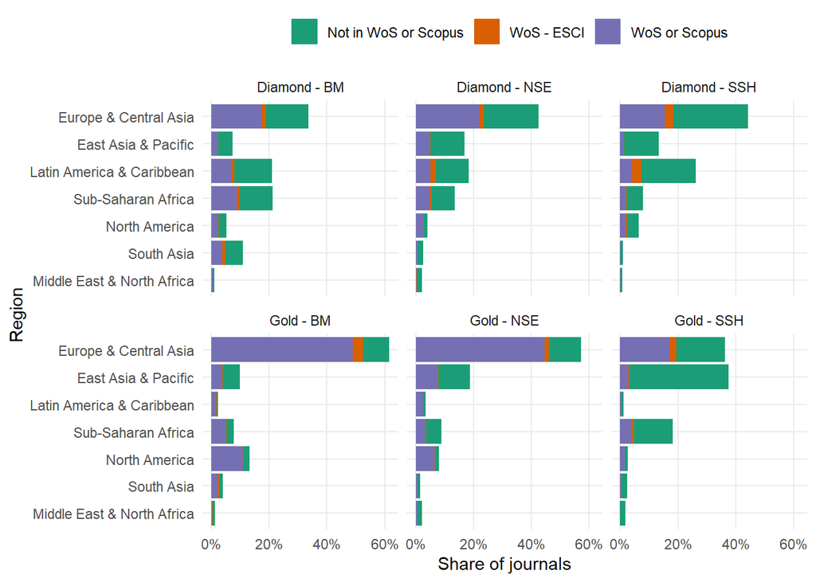

```r
plot_publisher_region <- doaj_journals %>%
  select(id, country_publisher_id, oa_type) %>%
  unique() %>%
  inner_join(doaj_coverage, by="id") %>%
  inner_join(doaj_countries_publishers, by=c("country_publisher_id"="id")) %>%
  inner_join(countries, by="country_code") %>%
  inner_join(journals_disciplines, by=c("id" = "doaj_id")) %>%
  filter(discipline != "n/a") %>%
  select(id, coverage, region, discipline, oa_type) %>%
  mutate(group = str_c(oa_type, " - ", discipline)) %>%
  group_by(group) %>%
  mutate(total = n()) %>%
  drop_na() %>%
  group_by(group, region, coverage) %>%
  reframe(n_journals = n(),
            p_journals = n_journals/total) %>%
  unique() %>%
  group_by(group, region) %>%
  mutate(x=sum(p_journals)) %>%
  ungroup() %>%
  ggplot() +
  aes(x=p_journals, y=reorder(region, x), fill=coverage) +
  scale_x_continuous(labels = scales::percent, breaks=c(0,0.2,0.4,0.6,0.8,1)) +
  geom_bar(stat="identity") +
  ylab("Region") +
  xlab("Share of journals") +
  theme_minimal() +
  theme(panel.grid.minor = element_blank()) +
  theme(plot.title = element_text(size = 10, hjust = .5)) +
  theme(legend.title=element_blank()) +
  theme(legend.position = "top") +
  scale_fill_brewer(palette = "Dark2") +
  facet_wrap(facets = "group")


plot_publisher_region$data %>%
  writexl::write_xlsx("tables and figures/publisher_region_data.xlsx")

plot_publisher_region
```

```r
ggsave("tables and figures/publisher_region.tiff", device = "tiff", width = 8, height = 5, units = "in", dpi=300)
```

### Publisher income group

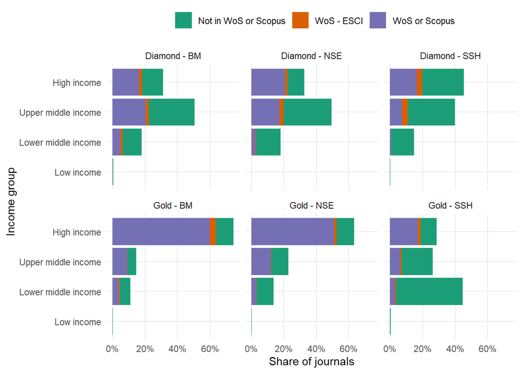

```r
plot_publisher_income_group <- doaj_journals %>%
  select(id, country_publisher_id, oa_type) %>%
  unique() %>%
  inner_join(doaj_coverage, by="id") %>%
  inner_join(doaj_countries_publishers, by=c("country_publisher_id"="id")) %>%
  inner_join(countries, by="country_code") %>%
  inner_join(journals_disciplines, by=c("id" = "doaj_id")) %>%
  filter(discipline != "n/a") %>%
  select(id, coverage, income_group, discipline, oa_type) %>%
  mutate(group = str_c(oa_type, " - ", discipline)) %>%
  group_by(group) %>%
  mutate(total = n()) %>%
  drop_na() %>%
  group_by(group, income_group, coverage) %>%
  reframe(n_journals = n(),
            p_journals = n_journals/total) %>%
  unique() %>%
  group_by(group, income_group) %>%
  mutate(x=sum(p_journals)) %>%
  ungroup() %>%
  mutate(income_group = factor(income_group,
                               levels=c("Low income",
                                        "Lower middle income",
                                        "Upper middle income",
                                        "High income"))) %>%

  ggplot() +
  aes(x=p_journals, y=income_group, fill=coverage) +
  scale_x_continuous(labels = scales::percent) +
  geom_bar(stat="identity") +
  ylab("Income group") +
  xlab("Share of journals") +
  theme_minimal() +
  theme(panel.grid.minor = element_blank()) +
  theme(plot.title = element_text(size = 10, hjust = .5)) +
  theme(legend.title=element_blank()) +
  theme(legend.position = "top") +
  scale_fill_brewer(palette = "Dark2") +
  facet_wrap(facets = "group")

plot_publisher_income_group
```

```r
plot_publisher_income_group$data %>%
  writexl::write_xlsx("tables and figures/publisher_income_group_data.xlsx")

ggsave("tables and figures/publisher_income_group.tiff", device = "tiff", width = 8, height = 5, units = "in", dpi=300)
```

### Publishing language

Here we divide journals in three groups:

1. **English** journals only publish in English
2. **Multiple languages** journals publish in English and at least one more language.
3. **Non-English** journals do not publish in English.

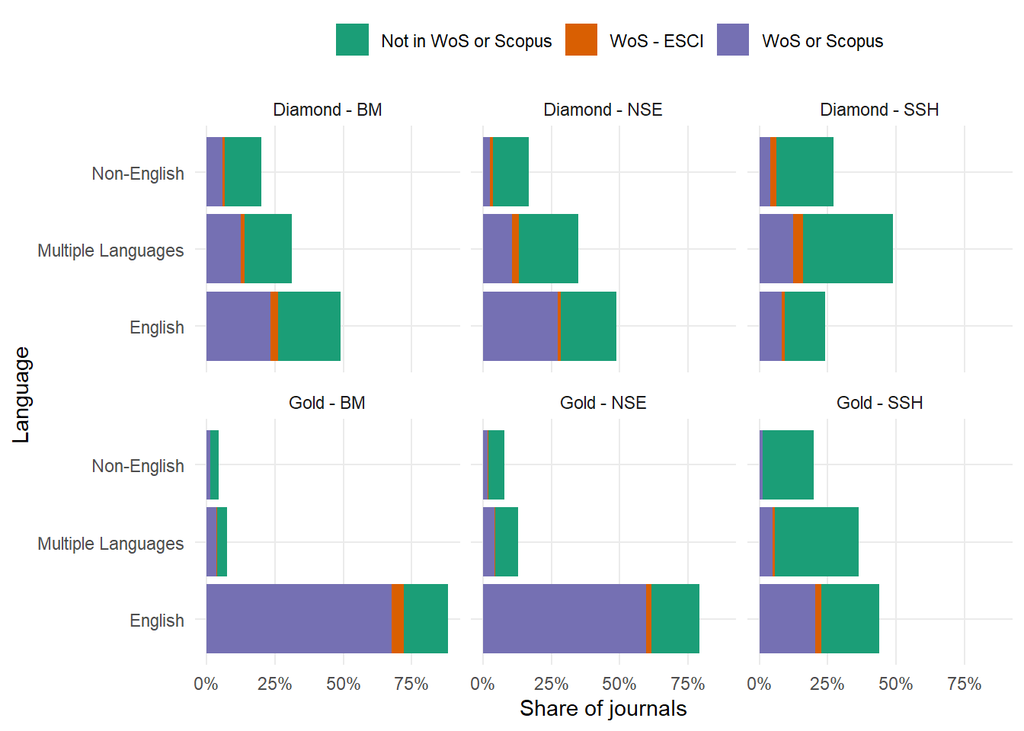

```r
n_lang <- doaj_languages %>%
  group_by(doaj_id) %>%
  summarize(n_lang = n())

journal_language<-doaj_languages %>%
  filter(language == "English") %>%
  filter(doaj_id %in% filter(n_lang, n_lang == 1)$doaj_id) %>%
  select(doaj_id) %>%
  mutate(language = "English") %>%
  unique()

# Classify journals in one of the three language groups
journal_language<-bind_rows(journal_language,
                            doaj_languages %>%
                              filter(language == "English") %>%
                              filter(doaj_id %in% filter(n_lang, n_lang > 1)$doaj_id) %>%
                            select(doaj_id) %>%
                            mutate(language = "Multiple Languages") %>%
                            unique())

journal_language<-bind_rows(journal_language,
                          doaj_languages %>%
                            filter(!doaj_id %in% journal_language$doaj_id) %>%
                            select(doaj_id) %>%
                            mutate(language = "Non-English") %>%
                            unique())


plot_publishing_language <- doaj_journals %>%
  select(id, oa_type) %>%
  unique() %>%
  inner_join(doaj_coverage, by="id") %>%
  inner_join(journal_language, by=c("id"="doaj_id")) %>%
  inner_join(journals_disciplines, by=c("id"="doaj_id")) %>%
  filter(discipline != "n/a") %>%
  select(id, coverage, language, discipline, oa_type) %>%
  mutate(group = str_c(oa_type, " - ", discipline)) %>%
  unique() %>%
  group_by(group) %>%
  mutate(total = n()) %>%
  ungroup() %>%
  drop_na() %>%
  group_by(group, language, coverage) %>%
  reframe(n_journals = n(),
            p_journals = n_journals/total) %>%
  ungroup() %>%
  unique() %>%
  group_by(language) %>%
  mutate(total_language=sum(n_journals)) %>%
  arrange(desc(total_language)) %>%
  ungroup() %>%
  ggplot() +
  aes(x=p_journals, y=language, fill=coverage) +
  scale_x_continuous(labels = scales::percent) +
  geom_bar(stat="identity") +
  ylab("Language") +
  xlab("Share of journals") +
  theme_minimal() +
  theme(panel.grid.minor = element_blank()) +
  theme(plot.title = element_text(size = 10, hjust = .5)) +
  theme(legend.title=element_blank()) +
  theme(legend.position = "top") +
  scale_fill_brewer(palette = "Dark2") +
  facet_wrap(facets = "group")

plot_publishing_language
```

```r
plot_publishing_language$data %>%
  writexl::write_xlsx("tables and figures/publisher_language_data.xlsx")

ggsave("tables and figures/publishing_language.tiff", device = "tiff", width = 8, height = 5, units = "in", dpi=300)
```

### Publisher countries (Gini)

```r
table_publisher_countries_gini <-
  data <- doaj_journals %>%
  select(id, country_publisher_id, oa_type) %>%
  unique() %>%
  inner_join(doaj_coverage, by="id") %>%
  inner_join(doaj_countries_publishers, by=c("country_publisher_id"="id")) %>%
  inner_join(journals_disciplines, by=c("id"="doaj_id")) %>%
  filter(discipline != "n/a")


write_xlsx(table_publisher_countries_gini %>%
             group_by(discipline, oa_type, coverage, country_code) %>%
             reframe(n_journals = n()),
           "tables and figures/data_journals_by_country.xlsx")


# Creates a combination of every journal and country code
x<-expand(countries,
          select(table_publisher_countries_gini,
                 id, coverage, discipline, oa_type),
          country_code) %>%
  unique()

table_publisher_countries_gini <-x %>%
  left_join(table_publisher_countries_gini %>%
              select(id, country_code) %>%
              mutate(n = 1),
            by=c("id", "country_code")) %>%
  mutate(n = ifelse(is.na(n),0,1)) %>%
  unique() %>%
  group_by(coverage, oa_type, discipline, country_code) %>%
  reframe(n = sum(n)) %>%
  group_by(coverage, oa_type, discipline) %>%
  summarize(gini = ineq(n,type="Gini")) %>%
  pivot_wider(names_from = "coverage", values_from = "gini") %>%
  drop_na()

table_publisher_countries_gini %>%
  kbl()
```

| oa_type | discipline | Not in WoS or Scopus | WoS - ESCI | WoS or Scopus |
| --- | --- | --- | --- | --- |
| Diamond | BM | 0.9081304 | 0.9382768 | 0.9181212 |
| Diamond | NSE | 0.9039658 | 0.9169850 | 0.8948191 |
| Diamond | SSH | 0.9086776 | 0.9378867 | 0.9055282 |
| Gold | BM | 0.9461987 | 0.9705903 | 0.9615593 |
| Gold | NSE | 0.9524853 | 0.9605911 | 0.9496604 |
| Gold | SSH | 0.9591767 | 0.9583750 | 0.9440742 |

## Authorship

### Author region

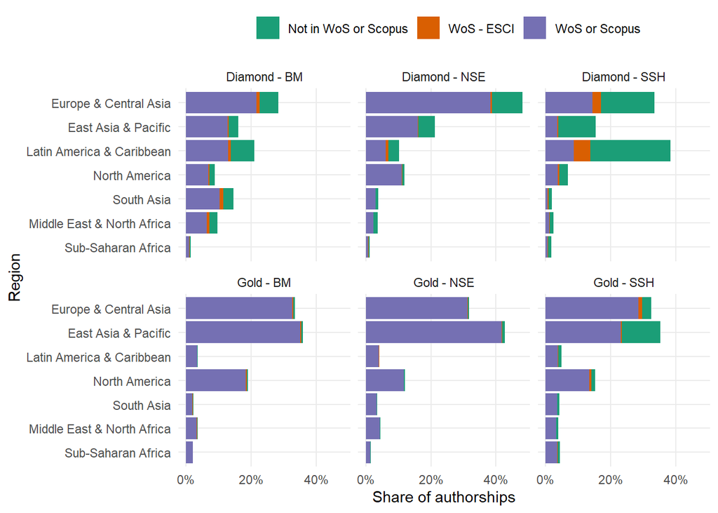

```r
plot_authorship_region <- doaj_journals %>%
  inner_join(doaj_openalex_matches, by=c("id"="doaj_id")) %>%
  left_join(openalex_authorship, by=c("openalex_id"="source_id")) %>%
  left_join(openalex_institutions, by=c("institution_id" = "id")) %>%
  left_join(countries, by="country_code") %>%
  inner_join(doaj_coverage, by="id") %>%
  inner_join(journals_disciplines, by=c("id" = "doaj_id")) %>%
  filter(discipline != "n/a") %>%
  mutate(group = str_c(oa_type, " - ", discipline)) %>%
  group_by(group) %>%
  drop_na() %>%
  mutate(total = sum(n_publications)) %>%
  group_by(group, region, coverage) %>%
  reframe(n_authorships = sum(n_publications),
            p_authorships = n_authorships/total) %>%
  unique() %>%
  group_by(group, region) %>%
  mutate(x=sum(p_authorships)) %>%
  ungroup() %>%
  ggplot() +
  aes(x=p_authorships, y=reorder(region, x), fill=coverage) +
  scale_x_continuous(labels = scales::percent, breaks=c(0,0.2,0.4,0.6,0.8,1)) +
  geom_bar(stat="identity") +
  ylab("Region") +
  xlab("Share of authorships") +
  theme_minimal() +
  theme(panel.grid.minor = element_blank()) +
  theme(plot.title = element_text(size = 10, hjust = .5)) +
  theme(legend.title=element_blank()) +
  theme(legend.position = "top") +
  scale_fill_brewer(palette = "Dark2") +
  facet_wrap(facets = "group")

plot_authorship_region
```

```r
plot_publisher_region$data %>%
  writexl::write_xlsx("tables and figures/authorships_region_data.xlsx")


ggsave("tables and figures/authorship_region.tiff", device = "tiff", width = 8, height = 5, units = "in", dpi=300)
```

### Author income group

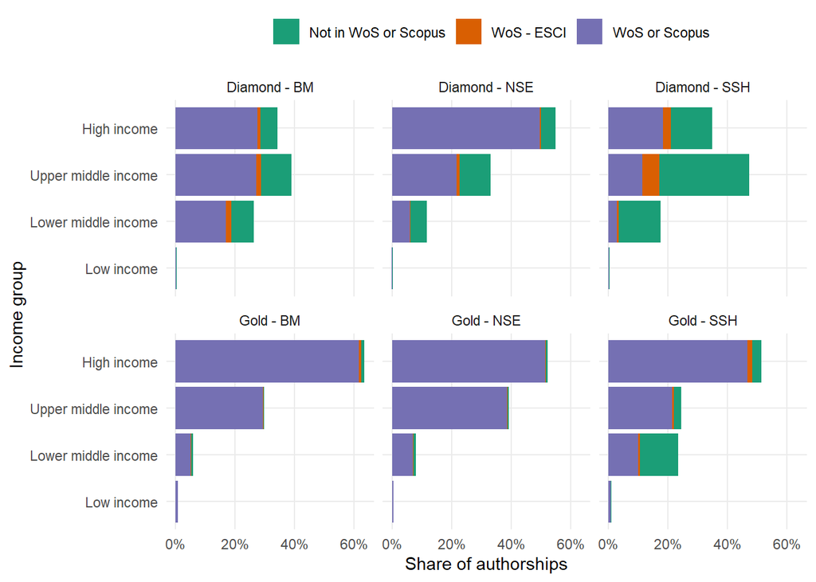

```r
plot_authorship_income_group <- doaj_journals %>%
  inner_join(doaj_openalex_matches, by=c("id"="doaj_id")) %>%
  left_join(openalex_authorship, by=c("openalex_id"="source_id")) %>%
  left_join(openalex_institutions, by=c("institution_id" = "id")) %>%
  left_join(countries, by="country_code") %>%
  inner_join(doaj_coverage, by="id") %>%
  inner_join(journals_disciplines, by=c("id" = "doaj_id")) %>%
  filter(discipline != "n/a") %>%
  mutate(group = str_c(oa_type, " - ", discipline)) %>%
  group_by(group) %>%
  drop_na() %>%
  mutate(total = sum(n_publications)) %>%
  group_by(group, income_group, coverage) %>%
  reframe(n_authorships = sum(n_publications),
            p_authorships = n_authorships/total) %>%
  unique() %>%
  group_by(group, income_group) %>%
  mutate(x=sum(p_authorships)) %>%
  ungroup() %>%
  ggplot() +
  aes(x=p_authorships, y=reorder(income_group, x), fill=coverage) +
  scale_x_continuous(labels = scales::percent, breaks=c(0,0.2,0.4,0.6,0.8,1)) +
  geom_bar(stat="identity") +
  ylab("Income group") +
  xlab("Share of authorships") +
  theme_minimal() +
  theme(panel.grid.minor = element_blank()) +
  theme(plot.title = element_text(size = 10, hjust = .5)) +
  theme(legend.title=element_blank()) +
  theme(legend.position = "top") +
  scale_fill_brewer(palette = "Dark2") +
  facet_wrap(facets = "group")

plot_authorship_income_group$data %>%
  writexl::write_xlsx("tables and figures/authorships_income_group_data.xlsx")

plot_authorship_income_group
```

```r
ggsave("tables and figures/authorship_income_group.tiff", device = "tiff", width = 8, height = 5, units = "in", dpi=300)
```

### Author countries (Gini)

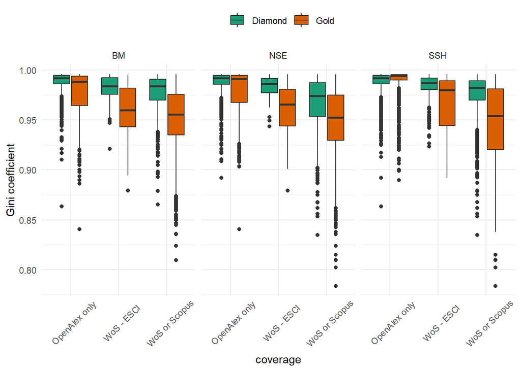

```r
countries_in_data <- openalex_authorship %>%
  inner_join(openalex_institutions, by=c("institution_id"="id")) %>%
  select(country_code) %>%
  drop_na() %>%
  unique()

authorship_gini_plot <- doaj_journals %>%
  inner_join(doaj_openalex_matches, by=c("id"="doaj_id")) %>%
  left_join(openalex_authorship, by=c("openalex_id"="source_id")) %>%
  left_join(openalex_institutions, by=c("institution_id" = "id")) %>%
  left_join(journals_disciplines, by=c("id"="doaj_id")) %>%
  left_join(doaj_coverage, by="id") %>%
  select(id, discipline, oa_type, coverage, country_code, n_publications) %>%
  group_by(id, discipline, oa_type, coverage, country_code) %>%
  reframe(n = sum(n_publications))

write_xlsx(authorship_gini_plot %>%
             group_by(discipline, oa_type, coverage, country_code) %>%
             reframe(total_authorship = sum(n)),
           "tables and figures/data_authorships_by_country.xlsx")

x<-expand(countries,
          doaj_journals %>% select(id),
          country_code) %>%
  inner_join(countries_in_data, by="country_code")

authorship_gini_plot <-x %>%
  left_join(authorship_gini_plot, by=c("id","country_code")) %>%
  mutate(n = ifelse(is.na(n),0,n)) %>%
  group_by(id) %>%
  mutate(gini = ineq(n,type="Gini")) %>%
  drop_na() %>%
  filter(discipline != "n/a") %>%
  mutate(discipline = as.factor(discipline),
         coverage = as.factor(coverage),
         oa_type = as.factor(oa_type)) %>%
  unique()

authorship_gini_plot %>%
  select(id, coverage, oa_type, discipline, gini) %>%
  filter(discipline != 'n/a') %>%
  unique() %>%
  mutate(coverage = as.character(coverage)) %>%
  mutate(coverage = ifelse(coverage == "Not in WoS or Scopus",
                           "OpenAlex only",
                           coverage)) %>%
  ggplot() +
  aes(x=coverage, y = gini, fill = oa_type) +
  geom_boxplot() +
  facet_wrap(facets = "discipline") +
  ylab("Gini coefficient") +
  xlab("coverage") +
  theme_minimal() +
  theme(legend.position = "top") +
  scale_fill_brewer(palette = "Dark2") +
  theme(axis.text.x = element_text(angle = 45)) +
  theme(axis.text.x = element_text(margin = margin(t = 20))) +
  theme(legend.title = element_blank()) +
  theme(axis.title.x = element_text(margin = margin(t = -15)))
```

```r
ggsave("tables and figures/authorship_gini.tiff", device = "tiff", width = 8, height = 5, units = "in", dpi=300)
```

#### Kruskall-Wallis test

```r
authorship_gini_plot<-authorship_gini_plot %>%
  ungroup() %>%
  mutate(group = str_c(oa_type, " - ", coverage)) %>%
  mutate(group = as.factor(group))

authorship_gini_plot %>%
  group_by(discipline) %>%
  kruskal_test(gini ~ group) %>%
  select(discipline, n, statistic, df, p) %>%
  inner_join(authorship_gini_plot %>%
               group_by(discipline) %>%
               kruskal_effsize(gini ~ group) %>%
               select(discipline, effsize, magnitude),
             by="discipline") %>%
  kbl()
```

| discipline | n | statistic | df | p | effsize | magnitude |
| --- | --- | --- | --- | --- | --- | --- |
| BM | 140356 | 34698.79 | 5 | 0 | 0.2471948 | large |
| NSE | 127369 | 27503.77 | 5 | 0 | 0.2159086 | large |
| SSH | 99600 | 35145.65 | 5 | 0 | 0.3528391 | large |

#### Pairwise Wilcoxon test

```r
authorship_gini_plot %>%
  filter(discipline == "BM") %>%
  wilcox_test(gini ~ group, p.adjust.method = "bonferroni") %>%
  select(-1) %>%
  kbl(caption = "Pairwise Wilcoxon test for BM journals")
```

Pairwise Wilcoxon test for BM journals

| group1 | group2 | n1 | n2 | statistic | p | p.adj | p.adj.signif |
| --- | --- | --- | --- | --- | --- | --- | --- |
| Diamond - Not in WoS or Scopus | Diamond - WoS - ESCI | 10551 | 1876 | 13696012 | 0 | 0 | **** |
| Diamond - Not in WoS or Scopus | Diamond - WoS or Scopus | 10551 | 21620 | 165080846 | 0 | 0 | **** |
| Diamond - Not in WoS or Scopus | Gold - Not in WoS or Scopus | 10551 | 8705 | 67648676 | 0 | 0 | **** |
| Diamond - Not in WoS or Scopus | Gold - WoS - ESCI | 10551 | 3683 | 33416252 | 0 | 0 | **** |
| Diamond - Not in WoS or Scopus | Gold - WoS or Scopus | 10551 | 93921 | 899097033 | 0 | 0 | **** |
| Diamond - WoS - ESCI | Diamond - WoS or Scopus | 1876 | 21620 | 22568556 | 0 | 0 | **** |
| Diamond - WoS - ESCI | Gold - Not in WoS or Scopus | 1876 | 8705 | 10267316 | 0 | 0 | **** |
| Diamond - WoS - ESCI | Gold - WoS - ESCI | 1876 | 3683 | 5391716 | 0 | 0 | **** |
| Diamond - WoS - ESCI | Gold - WoS or Scopus | 1876 | 93921 | 149528659 | 0 | 0 | **** |
| Diamond - WoS or Scopus | Gold - Not in WoS or Scopus | 21620 | 8705 | 107084083 | 0 | 0 | **** |
| Diamond - WoS or Scopus | Gold - WoS - ESCI | 21620 | 3683 | 56381925 | 0 | 0 | **** |
| Diamond - WoS or Scopus | Gold - WoS or Scopus | 21620 | 93921 | 1588441118 | 0 | 0 | **** |
| Gold - Not in WoS or Scopus | Gold - WoS - ESCI | 8705 | 3683 | 19549852 | 0 | 0 | **** |
| Gold - Not in WoS or Scopus | Gold - WoS or Scopus | 8705 | 93921 | 562692469 | 0 | 0 | **** |
| Gold - WoS - ESCI | Gold - WoS or Scopus | 3683 | 93921 | 206964867 | 0 | 0 | **** |

```r
authorship_gini_plot %>%
  filter(discipline == "NSE") %>%
  wilcox_test(gini ~ group, p.adjust.method = "bonferroni") %>%
  select(-1) %>%
  kbl(caption = "Pairwise Wilcoxon test for NSE journals")
```

Pairwise Wilcoxon test for NSE journals

| group1 | group2 | n1 | n2 | statistic | p | p.adj | p.adj.signif |
| --- | --- | --- | --- | --- | --- | --- | --- |
| Diamond - Not in WoS or Scopus | Diamond - WoS - ESCI | 11329 | 1623 | 10518550 | 0 | 0 | **** |
| Diamond - Not in WoS or Scopus | Diamond - WoS or Scopus | 11329 | 25271 | 224415720 | 0 | 0 | **** |
| Diamond - Not in WoS or Scopus | Gold - Not in WoS or Scopus | 11329 | 9673 | 73156915 | 0 | 0 | **** |
| Diamond - Not in WoS or Scopus | Gold - WoS - ESCI | 11329 | 1565 | 14653520 | 0 | 0 | **** |
| Diamond - Not in WoS or Scopus | Gold - WoS or Scopus | 11329 | 77908 | 779928144 | 0 | 0 | **** |
| Diamond - WoS - ESCI | Diamond - WoS or Scopus | 1623 | 25271 | 32241307 | 0 | 0 | **** |
| Diamond - WoS - ESCI | Gold - Not in WoS or Scopus | 1623 | 9673 | 10300465 | 0 | 0 | **** |
| Diamond - WoS - ESCI | Gold - WoS - ESCI | 1623 | 1565 | 2128887 | 0 | 0 | **** |
| Diamond - WoS - ESCI | Gold - WoS or Scopus | 1623 | 77908 | 114633754 | 0 | 0 | **** |
| Diamond - WoS or Scopus | Gold - Not in WoS or Scopus | 25271 | 9673 | 104319919 | 0 | 0 | **** |
| Diamond - WoS or Scopus | Gold - WoS - ESCI | 25271 | 1565 | 22707667 | 0 | 0 | **** |
| Diamond - WoS or Scopus | Gold - WoS or Scopus | 25271 | 77908 | 1349522587 | 0 | 0 | **** |
| Gold - Not in WoS or Scopus | Gold - WoS - ESCI | 9673 | 1565 | 9622416 | 0 | 0 | **** |
| Gold - Not in WoS or Scopus | Gold - WoS or Scopus | 9673 | 77908 | 549418991 | 0 | 0 | **** |
| Gold - WoS - ESCI | Gold - WoS or Scopus | 1565 | 77908 | 75215917 | 0 | 0 | **** |

```r
authorship_gini_plot %>%
  filter(discipline == "SSH") %>%
  wilcox_test(gini ~ group, p.adjust.method = "bonferroni") %>%
  select(-1) %>%
  kbl(caption = "Pairwise Wilcoxon test for SSH journals")
```

Pairwise Wilcoxon test for SSH journals

| group1 | group2 | n1 | n2 | statistic | p | p.adj | p.adj.signif |
| --- | --- | --- | --- | --- | --- | --- | --- |
| Diamond - Not in WoS or Scopus | Diamond - WoS - ESCI | 36878 | 6617 | 153026523 | 0.000 | 0 | **** |
| Diamond - Not in WoS or Scopus | Diamond - WoS or Scopus | 36878 | 29555 | 831561731 | 0.000 | 0 | **** |
| Diamond - Not in WoS or Scopus | Gold - Not in WoS or Scopus | 36878 | 8390 | 156609211 | 0.078 | 1 | ns |
| Diamond - Not in WoS or Scopus | Gold - WoS - ESCI | 36878 | 1478 | 44793631 | 0.000 | 0 | **** |
| Diamond - Not in WoS or Scopus | Gold - WoS or Scopus | 36878 | 16682 | 570289852 | 0.000 | 0 | **** |
| Diamond - WoS - ESCI | Diamond - WoS or Scopus | 6617 | 29555 | 131037690 | 0.000 | 0 | **** |
| Diamond - WoS - ESCI | Gold - Not in WoS or Scopus | 6617 | 8390 | 22912151 | 0.000 | 0 | **** |
| Diamond - WoS - ESCI | Gold - WoS - ESCI | 6617 | 1478 | 7386899 | 0.000 | 0 | **** |
| Diamond - WoS - ESCI | Gold - WoS or Scopus | 6617 | 16682 | 99053391 | 0.000 | 0 | **** |
| Diamond - WoS or Scopus | Gold - Not in WoS or Scopus | 29555 | 8390 | 78124342 | 0.000 | 0 | **** |
| Diamond - WoS or Scopus | Gold - WoS - ESCI | 29555 | 1478 | 27412302 | 0.000 | 0 | **** |
| Diamond - WoS or Scopus | Gold - WoS or Scopus | 29555 | 16682 | 398847420 | 0.000 | 0 | **** |
| Gold - Not in WoS or Scopus | Gold - WoS - ESCI | 8390 | 1478 | 9274796 | 0.000 | 0 | **** |
| Gold - Not in WoS or Scopus | Gold - WoS or Scopus | 8390 | 16682 | 121138229 | 0.000 | 0 | **** |
| Gold - WoS - ESCI | Gold - WoS or Scopus | 1478 | 16682 | 17471720 | 0.000 | 0 | **** |